# **Problem Statement**

## **Business Context**

Workplace safety in hazardous environments like construction sites and industrial plants is crucial to prevent accidents and injuries. One of the most important safety measures is ensuring workers wear safety helmets, which protect against head injuries from falling objects and machinery. Non-compliance with helmet regulations increases the risk of serious injuries or fatalities, making effective monitoring essential, especially in large-scale operations where manual oversight is prone to errors and inefficiency.

To overcome these challenges, SafeGuard Corp plans to develop an automated image analysis system capable of detecting whether workers are wearing safety helmets. This system will improve safety enforcement, ensuring compliance and reducing the risk of head injuries. By automating helmet monitoring, SafeGuard aims to enhance efficiency, scalability, and accuracy, ultimately fostering a safer work environment while minimizing human error in safety oversight.

## **Objective**

As a data scientist at SafeGuard Corp, you are tasked with developing an image classification model that classifies images into one of two categories:

- **With Helmet:** Workers wearing safety helmets.
- **Without Helmet:** Workers not wearing safety helmets.

## **Data Description**

- **With Helmet:** 311 images showing workers wearing helmets.
- **Without Helmet:** 320 images showing workers not wearing helmets.

**Dataset Characteristics:**

- **Variations in Conditions:** Images include diverse environments such as construction sites, factories, and industrial settings, with variations in lighting, angles, and worker postures to simulate real-world conditions.
- **Worker Activities:** Workers are depicted in different actions such as standing, using tools, or moving, ensuring robust model learning for various scenarios.

# **Installing and Importing the Necessary Libraries**

```python
!pip install tensorflow[and-cuda] numpy==1.25.2 -q
```

[output not shown]

```python
import tensorflow as tf
print("Num GPUs Available:", len(tf.config.list_physical_devices('GPU')))
print(tf.__version__)
```

```
Num GPUs Available: 1
2.19.0
```

**Note:**

- After running the above cell, kindly restart the notebook kernel (for Jupyter Notebook) or runtime (for Google Colab) and run all cells sequentially from the next cell.
- On executing the above line of code, you might see a warning regarding package dependencies. This error message can be ignored as the above code ensures that all necessary libraries and their dependencies are maintained to successfully execute the code in this notebook.

```python
import os
import random
import numpy as np                                                                               # Importing numpy for Matrix Operations
import pandas as pd
import seaborn as sns
import matplotlib.image as mpimg                                                                              # Importing pandas to read CSV files
import matplotlib.pyplot as plt                                                                  # Importting matplotlib for Plotting and visualizing images
import math                                                                                      # Importing math module to perform mathematical operations
import cv2


# Tensorflow modules
import keras
import tensorflow as tf
from tensorflow.keras.preprocessing.image import ImageDataGenerator                              # Importing the ImageDataGenerator for data augmentation
from tensorflow.keras.models import Sequential                                                   # Importing the sequential module to define a sequential model
from tensorflow.keras.layers import Dense,Dropout,Flatten,Conv2D,MaxPooling2D,BatchNormalization # Defining all the layers to build our CNN Model
from tensorflow.keras.optimizers import Adam,SGD                                                 # Importing the optimizers which can be used in our model
from sklearn import preprocessing                                                                # Importing the preprocessing module to preprocess the data
from sklearn.model_selection import train_test_split                                             # Importing train_test_split function to split the data into train and test
from sklearn.metrics import confusion_matrix
from tensorflow.keras.models import Model
from keras.applications.vgg16 import VGG16                                               # Importing confusion_matrix to plot the confusion matrix

# Display images using OpenCV
from google.colab.patches import cv2_imshow

#Imports functions for evaluating the performance of machine learning models
from sklearn.metrics import confusion_matrix, f1_score,accuracy_score, recall_score, precision_score, classification_report
from sklearn.metrics import mean_squared_error as mse                                                 # Importing cv2_imshow from google.patches to display images

# Ignore warnings
import warnings
warnings.filterwarnings('ignore')
```

```python
# Set the seed using keras.utils.set_random_seed. This will set:
# 1) `numpy` seed
# 2) backend random seed
# 3) `python` random seed
tf.keras.utils.set_random_seed(812)
```

# **Data Overview**

```python
from google.colab import drive
drive.mount('/content/drive')
```

# **Exploratory Data Analysis**

```python
# Load image data and labels
X = np.load('/content/drive/MyDrive/helmnet/images_proj.npy')  # shape should be (631, H, W, C)
y_df = pd.read_csv('/content/drive/MyDrive/helmnet/Labels_proj.csv')  # should contain binary labels
```

**Observation:**

- Imported all libraries
- Imported data from google drive

```python
# Inspect dimensions
print(f"Image Data Shape: {X.shape}")
print(f"Labels DataFrame Shape: {y_df.shape}")
print(y_df.head())
```

```
Image Data Shape: (631, 200, 200, 3)
Labels DataFrame Shape: (631, 1)
   Label
0      1
1      1
2      1
3      1
4      1
```

** Observation **

- The data consists of 631 images which are 200px x 200px RGB 3 channel images.
- There are also 631 labels with a datashape of 1 column named "Label" to indicate helmet or no helmet

## Convert Labels to Numpy Array

```python
# Convert labels to a flat Numpy Array to view the classes
y = y_df['Label'].values  # shape will be (631,)
print(f"y shape: {y.shape}")
print(f"Unique classes: {np.unique(y)}")
```

```
y shape: (631,)
Unique classes: [0 1]
```

** Observation **

- 631 labels as a flat NumPy array as expected
- Should return [0, 1] for binary labels indicating with helmet (1) or no helmet (0).

### Plot random images from each of the classes and print their corresponding labels.

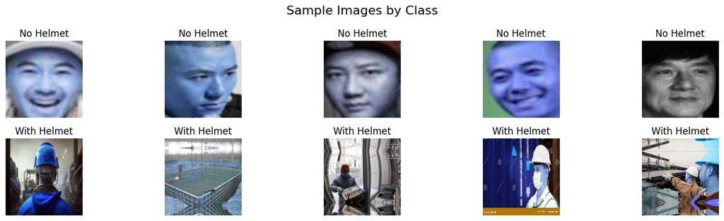

```python
# Show sample images
# Convert to NumPy array if not already
X = np.array(X)
y = np.array(y)

# Find indices for each class
helmet_indices = np.where(y == 1)[0]
no_helmet_indices = np.where(y == 0)[0]

# Pick 5 random indices from each
helmet_samples = random.sample(list(helmet_indices), 5)
no_helmet_samples = random.sample(list(no_helmet_indices), 5)

# Plot images without helmet
plt.figure(figsize=(15, 4))
for i, idx in enumerate(no_helmet_samples):
    plt.subplot(2, 5, i+1)
    plt.imshow(X[idx].squeeze(), cmap='gray' if X.shape[-1] == 1 else None) # Ensures any grayscale images are shown correctly
    plt.title("No Helmet")
    plt.axis('off')

# Plot images with helmet
for i, idx in enumerate(helmet_samples):
    plt.subplot(2, 5, i+6)
    plt.imshow(X[idx].squeeze(), cmap='gray' if X.shape[-1] == 1 else None)
    plt.title("With Helmet")
    plt.axis('off')

plt.suptitle("Sample Images by Class", fontsize=16)
plt.tight_layout()
plt.show()
```

## Checking for class imbalance

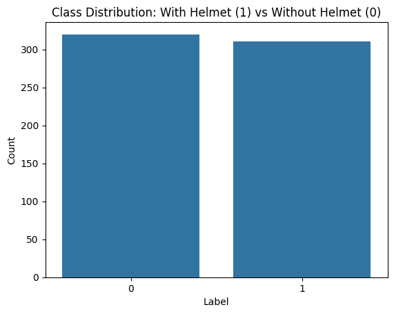

```python
# Plot the class distribution with Seaborn countplot.
sns.countplot(x=y_df['Label'])
plt.title("Class Distribution: With Helmet (1) vs Without Helmet (0)")
plt.xlabel("Label")
plt.ylabel("Count")
plt.show()
```

** OBSERVATION: **

- Label classification is pretty evenly distributed 320 with no helmet and 311 with helmet.

# **Data Preprocessing**

## Converting images to grayscale

```python
# Convert RGB images to Grayscale
X_gray = np.array([cv2.cvtColor(img, cv2.COLOR_RGB2GRAY) for img in X])

# Reshape to match CNN input (samples, height, width, channels)
X_gray = X_gray.reshape(X_gray.shape[0], X_gray.shape[1], X_gray.shape[2], 1)

# Confirm shape
print(f"X_gray shape: {X_gray.shape}")
```

```
X_gray shape: (631, 200, 200, 1)
```

[figure not shown]

```python
helmet_indices = np.where(y == 1)[0]
no_helmet_indices = np.where(y == 0)[0]

# Pick 5 random indices from each
helmet_gray_samples = random.sample(list(helmet_indices), 5)
no_helmet_gray_samples = random.sample(list(no_helmet_indices), 5)

plt.figure(figsize=(15, 6))

# Plot images without helmet
for i, idx in enumerate(no_helmet_gray_samples):
    plt.subplot(2, 5, i + 1)
    plt.imshow(X_gray[idx].squeeze(), cmap='gray')
    plt.title("No Helmet (Grayscale)")
    plt.axis('off')

# Plot images with helmet
for i, idx in enumerate(helmet_gray_samples):
    plt.subplot(2, 5, i + 6)
    plt.imshow(X_gray[idx].squeeze(), cmap='gray')
    plt.title("With Helmet (Grayscale)")
    plt.axis('off')

plt.suptitle("Sample Grayscale Images by Class", fontsize=16)
plt.tight_layout()
plt.show()
```

### Splitting the dataset 70/15/15 for train/validation/test

```python
# First split: 70% train, 30% temp (val+test)
X_train, X_temp, y_train, y_temp = train_test_split(
    X_gray, y, test_size=0.3, random_state=42, stratify=y
)

# Second split: 50% of the temp set goes to val, 50% to test
X_val, X_test, y_val, y_test = train_test_split(
    X_temp, y_temp, test_size=0.5, random_state=42, stratify=y_temp
)
```

## Final Ratio

```python
print(f"Train set: {X_train.shape[0]}")
print(f"Validation set: {X_val.shape[0]}")
print(f"Test set: {X_test.shape[0]}")
```

```
Train set: 441
Validation set: 95
Test set: 95
```

### Data Normalization

```python
# Since pixel values are currently in the range [0, 255] (as is typical for images), we’ll scale them to the range [0.0, 1.0] by dividing by 255
# Normalize grayscale pixel values to [0.0, 1.0]
X_train = X_train / 255.0
X_val = X_val / 255.0
X_test = X_test / 255.0
```

## Validation Normalization

```python
print(f"Train min: {X_train.min()}, max: {X_train.max()}")
print(f"Val min: {X_val.min()}, max: {X_val.max()}")
print(f"Test min: {X_test.min()}, max: {X_test.max()}")
```

```
Train min: 0.0, max: 1.0
Val min: 0.0, max: 1.0
Test min: 0.0, max: 1.0
```

** OBSERVATION: **

- From the above min/max values we can see that are now between 0.0 and 1.0 as expected and required to feed into our CNN.

# **Model Building**

## Model Evaluation Criterion

Because Accuracy is paramount in classifying whether a person is wearing a safety helmet or not, we'll evaluate model performance on the criteria of Accuracy scores.

## Utility Functions

```python
# defining a function to compute different metrics to check performance of a classification model built using statsmodels
def model_performance_classification(model, predictors, target):
    """
    Function to compute different metrics to check classification model performance

    model: classifier
    predictors: independent variables
    target: dependent variable
    """

    # checking which probabilities are greater than threshold
    pred = model.predict(predictors).reshape(-1)>0.5

    target = target.to_numpy().reshape(-1)


    acc = accuracy_score(target, pred)  # to compute Accuracy
    recall = recall_score(target, pred, average='weighted')  # to compute Recall
    precision = precision_score(target, pred, average='weighted')  # to compute Precision
    f1 = f1_score(target, pred, average='weighted')  # to compute F1-score

    # creating a dataframe of metrics
    df_perf = pd.DataFrame({"Accuracy": acc, "Recall": recall, "Precision": precision, "F1 Score": f1,},index=[0],)

    return df_perf
```

```python
def plot_confusion_matrix(model,predictors,target,ml=False):
    """
    Function to plot the confusion matrix

    model: classifier
    predictors: independent variables
    target: dependent variable
    ml: To specify if the model used is an sklearn ML model or not (True means ML model)
    """

    # checking which probabilities are greater than threshold
    pred = model.predict(predictors).reshape(-1)>0.5

    target = target.to_numpy().reshape(-1)

    # Plotting the Confusion Matrix using confusion matrix() function which is also predefined tensorflow module
    confusion_matrix = tf.math.confusion_matrix(target,pred)
    f, ax = plt.subplots(figsize=(10, 8))
    sns.heatmap(
        confusion_matrix,
        annot=True,
        linewidths=.4,
        fmt="d",
        square=True,
        ax=ax
    )
    plt.show()
```

## Model 1: Simple Convolutional Neural Network (CNN)

I'll use a simple architecture with two convolution layers, followed by dense layers.

The model has 2 main parts:

The Feature Extraction layers which are comprised of convolutional and pooling layers. The Fully Connected classification layers for prediction.

```python
# Define the CNN architecture
cnn_model_1 = Sequential([
    Conv2D(32, (3, 3), activation='relu', input_shape=X_train.shape[1:]),
    MaxPooling2D(pool_size=(2, 2)),

    Conv2D(64, (3, 3), activation='relu'),
    MaxPooling2D(pool_size=(2, 2)),

    Flatten(),
    Dense(128, activation='relu'),
    Dropout(0.5),
    Dense(1, activation='sigmoid')  # Output layer for binary classification
])

# Compile the model
cnn_model_1.compile(optimizer='adam',
                  loss='binary_crossentropy',
                  metrics=['accuracy'])

# Display model summary
cnn_model_1.summary()
```

```
Model: "sequential"
```

```
┏━━━━━━━━━━━━━━━━━━━━━━━━━━━━━━━━━┳━━━━━━━━━━━━━━━━━━━━━━━━┳━━━━━━━━━━━━━━━┓
┃ Layer (type)                    ┃ Output Shape           ┃       Param # ┃
┡━━━━━━━━━━━━━━━━━━━━━━━━━━━━━━━━━╇━━━━━━━━━━━━━━━━━━━━━━━━╇━━━━━━━━━━━━━━━┩
│ conv2d (Conv2D)                 │ (None, 198, 198, 32)   │           320 │
├─────────────────────────────────┼────────────────────────┼───────────────┤
│ max_pooling2d (MaxPooling2D)    │ (None, 99, 99, 32)     │             0 │
├─────────────────────────────────┼────────────────────────┼───────────────┤
│ conv2d_1 (Conv2D)               │ (None, 97, 97, 64)     │        18,496 │
├─────────────────────────────────┼────────────────────────┼───────────────┤
│ max_pooling2d_1 (MaxPooling2D)  │ (None, 48, 48, 64)     │             0 │
├─────────────────────────────────┼────────────────────────┼───────────────┤
│ flatten_1 (Flatten)             │ (None, 147456)         │             0 │
├─────────────────────────────────┼────────────────────────┼───────────────┤
│ dense_3 (Dense)                 │ (None, 128)            │    18,874,496 │
├─────────────────────────────────┼────────────────────────┼───────────────┤
│ dropout_2 (Dropout)             │ (None, 128)            │             0 │
├─────────────────────────────────┼────────────────────────┼───────────────┤
│ dense_4 (Dense)                 │ (None, 1)              │           129 │
└─────────────────────────────────┴────────────────────────┴───────────────┘
```

```
 Total params: 18,893,441 (72.07 MB)
```

```
 Trainable params: 18,893,441 (72.07 MB)
```

```
 Non-trainable params: 0 (0.00 B)
```

```python
history_1 = cnn_model_1.fit(
    X_train, y_train,
    validation_data=(X_val, y_val),
    epochs=10,
    batch_size=32,
    verbose=2
)
```

[output not shown]

### Vizualizing the predictions

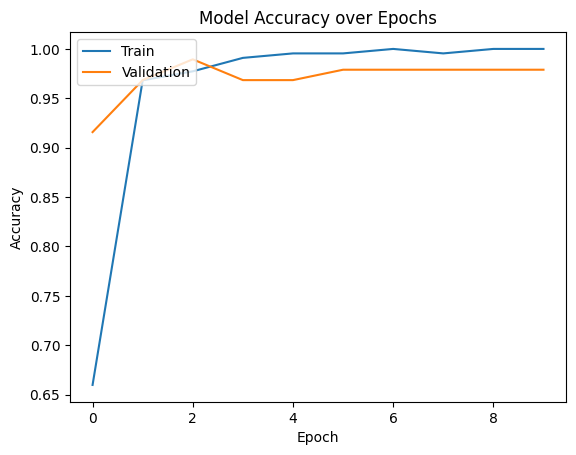

```python
plt.plot(history_1.history['accuracy'])
plt.plot(history_1.history['val_accuracy'])
plt.title('Model Accuracy over Epochs')
plt.ylabel('Accuracy')
plt.xlabel('Epoch')
plt.legend(['Train', 'Validation'], loc='upper left')
plt.show()
```

** Observation**

- From the above graph, we see a sharp ramp up of training data performance to 1 by around epoch 4. This may be overfitting on training data.
- The validation data accuracy remains high (~97%) and relatively stable throughout.

```
Train performance metrics:
14/14 ━━━━━━━━━━━━━━━━━━━━ 2s 96ms/step
```

|  | Accuracy | Recall | Precision | F1 Score |
| --- | --- | --- | --- | --- |
| 0 | 1.0 | 1.0 | 1.0 | 1.0 |

```
14/14 ━━━━━━━━━━━━━━━━━━━━ 0s 10ms/step
```

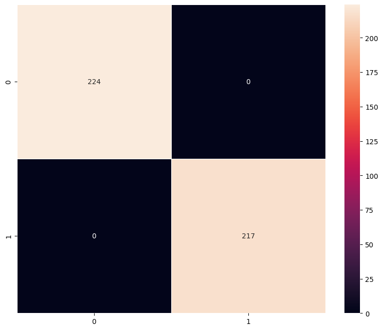

```
Validation performance metrics:
3/3 ━━━━━━━━━━━━━━━━━━━━ 0s 177ms/step
```

|  | Accuracy | Recall | Precision | F1 Score |
| --- | --- | --- | --- | --- |
| 0 | 0.978947 | 0.978947 | 0.978947 | 0.978947 |

```
============================================================
CONFUSION MATRIX
============================================================

3/3 ━━━━━━━━━━━━━━━━━━━━ 0s 18ms/step
```

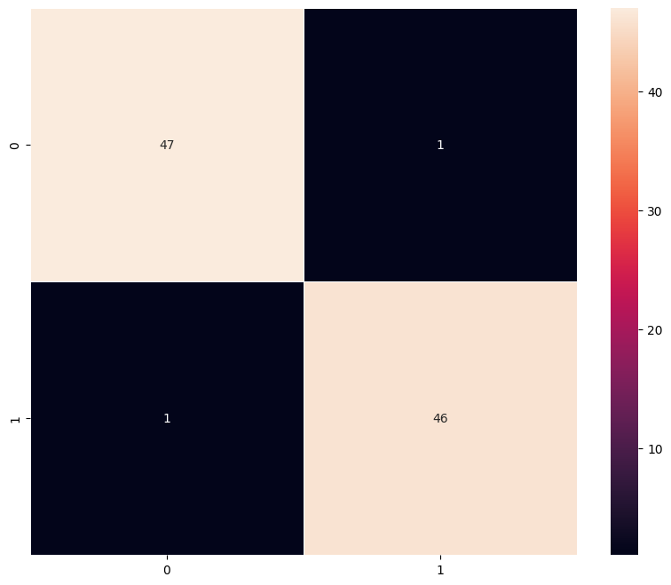

```python
# Evaluate on Train Set
print("Train performance metrics:")
cnn_model_1_train_perf = model_performance_classification(cnn_model_1, X_train, pd.Series(y_train))
display(cnn_model_1_train_perf)

plot_confusion_matrix(cnn_model_1, X_train, pd.Series(y_train))

# Evaluate on Validation Set
print("Validation performance metrics:")
cnn_model_1_val_perf = model_performance_classification(cnn_model_1, X_val, pd.Series(y_val))
display(cnn_model_1_val_perf)

print("\n" + "=" * 60)
print("CONFUSION MATRIX")
print("=" * 60 + "\n") # print separator line

plot_confusion_matrix(cnn_model_1, X_val, pd.Series(y_val))

# Evaluate on Test Set
# print("Test performance metrics:")
# cnn_model_1_test_perf = model_performance_classification(cnn_model_1, X_test, pd.Series(y_test))
# display(cnn_model_1_test_perf)

# print("\n" + "=" * 60)
# print("CONFUSION MATRIX")
# print("=" * 60 + "\n") # print separator line

# plot_confusion_matrix(cnn_model_1, X_test, pd.Series(y_test))
```

** OBSERVATION: **

- From the above confusion matrices for the base CNN model I can see it scored perfect on the training data for all performance metrics.
- It may be overfitting on the training data.
- It scored high (~97%) Accuracy on the validation data on the base mode. This may be based on a small image library of 631 images.

** Visualization of Predictions **

```
1/1 ━━━━━━━━━━━━━━━━━━━━ 1s 653ms/step
Predicted Label: 1
True Label: 1
```

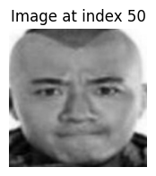

```
1/1 ━━━━━━━━━━━━━━━━━━━━ 0s 30ms/step
Predicted Label: 0
True Label: 0
```

```python
# Visualize and predict for index 12
index = 12
plt.figure(figsize=(2,2))
plt.imshow(X_val[index].reshape(X_val.shape[1], X_val.shape[2]), cmap='gray')
plt.title(f"Image at index {index}")
plt.axis('off')
plt.show()

# Make prediction
prediction = cnn_model_1.predict(X_val[index].reshape(1, X_val.shape[1], X_val.shape[2], 1))
predicted_label = 1 if prediction[0][0] > 0.5 else 0
print('Predicted Label:', predicted_label)
print('True Label:', y_val[index])

# Repeat for index 33
index = 50
plt.figure(figsize=(2,2))
plt.imshow(X_val[index].reshape(X_val.shape[1], X_val.shape[2]), cmap='gray')
plt.title(f"Image at index {index}")
plt.axis('off')
plt.show()

prediction = cnn_model_1.predict(X_val[index].reshape(1, X_val.shape[1], X_val.shape[2], 1))
predicted_label = 1 if prediction[0][0] > 0.5 else 0
print('Predicted Label:', predicted_label)
print('True Label:', y_val[index])
```

[output not shown]

** OBSERVATION: **

- From the above prediction, we can see that the model predicted both images correctly.

```python
history_2_epoch15 = cnn_model_1.fit(
    X_train, y_train,
    validation_data=(X_val, y_val),
    epochs=15,
    batch_size=32,
    verbose=2
)
```

```
14/14 - 1s - 67ms/step - accuracy: 1.0000 - loss: 4.6220e-05 - val_accuracy: 0.9789 - val_loss: 0.1351
14/14 - 1s - 44ms/step - accuracy: 1.0000 - loss: 1.2885e-04 - val_accuracy: 0.9789 - val_loss: 0.1348
14/14 - 1s - 45ms/step - accuracy: 1.0000 - loss: 0.0016 - val_accuracy: 0.9789 - val_loss: 0.1334
14/14 - 1s - 88ms/step - accuracy: 1.0000 - loss: 4.3737e-05 - val_accuracy: 0.9789 - val_loss: 0.1341
14/14 - 1s - 44ms/step - accuracy: 1.0000 - loss: 6.4024e-05 - val_accuracy: 0.9789 - val_loss: 0.1372
14/14 - 1s - 39ms/step - accuracy: 1.0000 - loss: 1.3147e-04 - val_accuracy: 0.9789 - val_loss: 0.1384
14/14 - 1s - 39ms/step - accuracy: 1.0000 - loss: 5.7974e-04 - val_accuracy: 0.9684 - val_loss: 0.1398
14/14 - 1s - 38ms/step - accuracy: 1.0000 - loss: 1.7296e-04 - val_accuracy: 0.9684 - val_loss: 0.1433
14/14 - 1s - 39ms/step - accuracy: 1.0000 - loss: 8.0060e-05 - val_accuracy: 0.9789 - val_loss: 0.1357
14/14 - 1s - 39ms/step - accuracy: 1.0000 - loss: 1.3436e-04 - val_accuracy: 0.9789 - val_loss: 0.1379
14/14 - 1s - 39ms/step - accuracy: 1.0000 - loss: 3.5671e-05 - val_accuracy: 0.9789 - val_loss: 0.1385
14/14 - 1s - 39ms/step - accuracy: 1.0000 - loss: 1.6085e-05 - val_accuracy: 0.9789 - val_loss: 0.1386
14/14 - 1s - 39ms/step - accuracy: 1.0000 - loss: 1.9341e-05 - val_accuracy: 0.9789 - val_loss: 0.1385
14/14 - 1s - 39ms/step - accuracy: 1.0000 - loss: 2.1916e-04 - val_accuracy: 0.9789 - val_loss: 0.1389
14/14 - 1s - 39ms/step - accuracy: 1.0000 - loss: 1.8454e-04 - val_accuracy: 0.9789 - val_loss: 0.1400
```

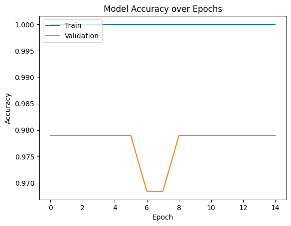

```python
plt.plot(history_2_epoch15.history['accuracy'])
plt.plot(history_2_epoch15.history['val_accuracy'])
plt.title('Model Accuracy over Epochs')
plt.ylabel('Accuracy')
plt.xlabel('Epoch')
plt.legend(['Train', 'Validation'], loc='upper left')
plt.show()
```

** Observation:**